# GC_Content

Pearson’s coefficient

```r
attach(dvg2)
round(cor(cbind(dN.dS,AlnLength,GCProp)),2)
```

```
          dN.dS AlnLength GCProp
dN.dS      1.00     -0.11  -0.13
AlnLength -0.11      1.00   0.05
GCProp    -0.13      0.05   1.00
```

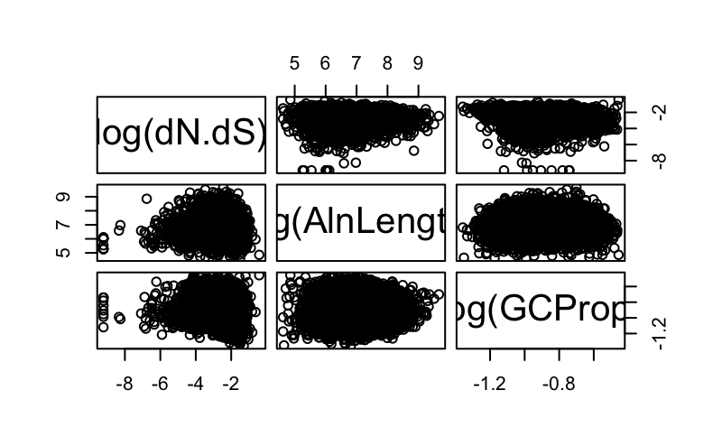

```r
pairs(~log(dN.dS)+log(AlnLength)+log(GCProp),
      gap = .5)
```

… Are they linear ?? So many datapoints.

```r
lm1 <- lm(dN.dS ~ GCProp, data = dvg2)
summary(lm1)
```

```
Call:
lm(formula = dN.dS ~ GCProp, data = dvg2)

Residuals:
     Min       1Q   Median       3Q      Max
-0.09807 -0.04448 -0.01084  0.03174  0.59376

Coefficients:
             Estimate Std. Error t value Pr(>|t|)
(Intercept)  0.133411   0.004575  29.163   <2e-16 ***
GCProp      -0.109916   0.011099  -9.904   <2e-16 ***
---
Signif. codes:  0 ‘***’ 0.001 ‘**’ 0.01 ‘*’ 0.05 ‘.’ 0.1 ‘ ’ 1

Residual standard error: 0.06115 on 5965 degrees of freedom
Multiple R-squared:  0.01618,   Adjusted R-squared:  0.01601
F-statistic: 98.08 on 1 and 5965 DF,  p-value: < 2.2e-16
```

```r
lm2 <- lm(dN.dS ~ GCProp + AlnLength, data = dvg2)
summary(lm2)
```

```
Call:
lm(formula = dN.dS ~ GCProp + AlnLength, data = dvg2)

Residuals:
     Min       1Q   Median       3Q      Max
-0.10418 -0.04344 -0.01064  0.03199  0.58580

Coefficients:
              Estimate Std. Error t value Pr(>|t|)
(Intercept)  1.395e-01  4.614e-03  30.240  < 2e-16 ***
GCProp      -1.059e-01  1.105e-02  -9.584  < 2e-16 ***
AlnLength   -5.469e-06  6.825e-07  -8.013 1.33e-15 ***
---
Signif. codes:  0 ‘***’ 0.001 ‘**’ 0.01 ‘*’ 0.05 ‘.’ 0.1 ‘ ’ 1

Residual standard error: 0.06083 on 5964 degrees of freedom
Multiple R-squared:  0.02666,   Adjusted R-squared:  0.02633
F-statistic: 81.67 on 2 and 5964 DF,  p-value: < 2.2e-16
```

```r
vif(lm2)
```

```
   GCProp AlnLength
 1.002041  1.002041
```

Tolerance should be about 1. So these are fine.

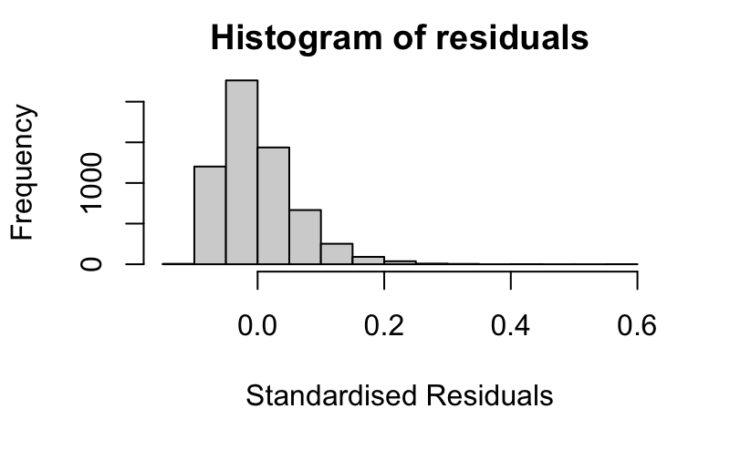

```r
hist(resid(lm2),main='Histogram of residuals',xlab='Standardised Residuals',ylab='Frequency')
```

These are not normally distributed which breaks the assumption of normality.

And just for completion …

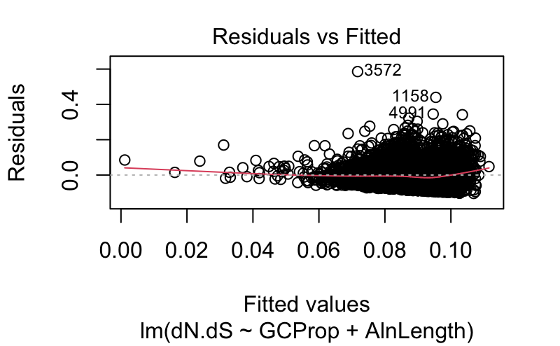

Much bunching in the scatterplot. Not exactly spread out.

```r
lm3 <- lm(log(dN.dS) ~ log(GeneAverage) + log(AlnLength), data = dvg2)
summary(lm3)
```

```
Call:
lm(formula = log(dN.dS) ~ log(GeneAverage) + log(AlnLength),
    data = dvg2)

Residuals:
    Min      1Q  Median      3Q     Max
-6.6293 -0.4212  0.1537  0.5840  2.6054

Coefficients:
                  Estimate Std. Error t value Pr(>|t|)
(Intercept)      -0.281643   0.267562  -1.053    0.293
log(GeneAverage) -0.664336   0.067517  -9.840   <2e-16 ***
log(AlnLength)    0.002699   0.016049   0.168    0.866
---
Signif. codes:  0 ‘***’ 0.001 ‘**’ 0.01 ‘*’ 0.05 ‘.’ 0.1 ‘ ’ 1

Residual standard error: 0.8839 on 5964 degrees of freedom
Multiple R-squared:  0.016, Adjusted R-squared:  0.01567
F-statistic: 48.49 on 2 and 5964 DF,  p-value: < 2.2e-16
```

Still significant relationship between GC and evolutionary rate however …

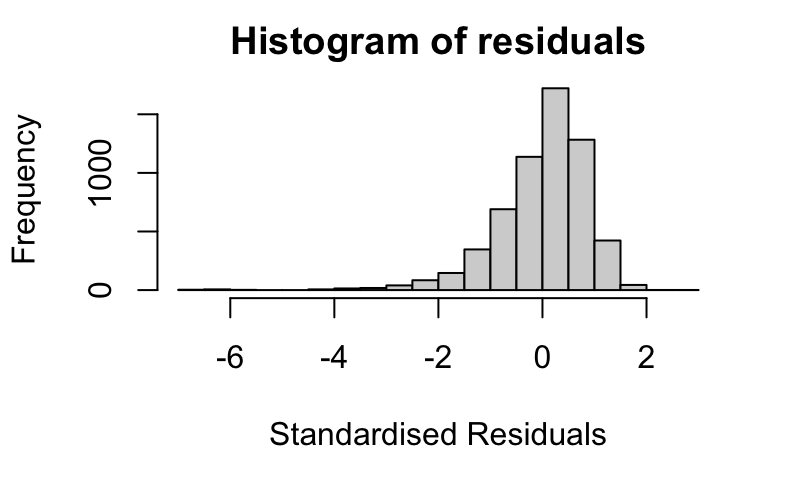

```r
hist(resid(lm3),main='Histogram of residuals',xlab='Standardised Residuals',ylab='Frequency')
```

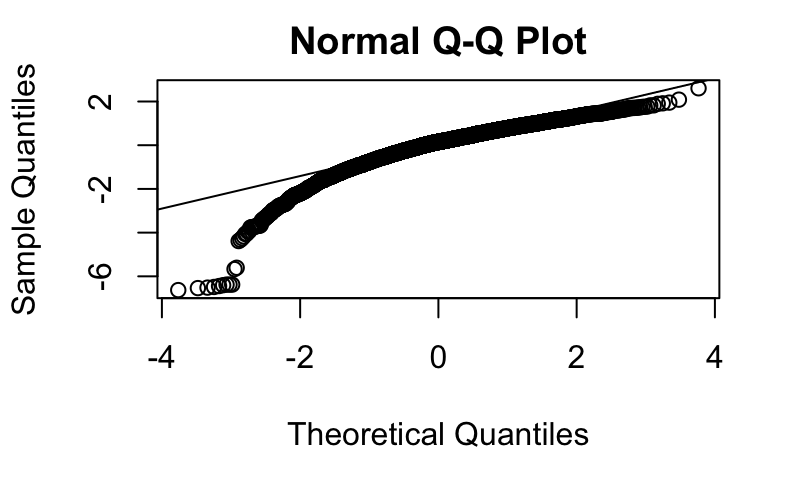

```r
qqnorm(resid(lm3))
qqline(resid(lm3))
```

|  | Gene | dN.dS | AlnLength | GeneAverage | Function | Codon | GCProp |
| --- | --- | --- | --- | --- | --- | --- | --- |
| 4654 | LOC724292 | 0.07726 | 1482 | 51.29364 | NA | 494 | 0.5129364 |

I now have a preliminary list of non-canon genes to play with.

```r
dvg3 <- read.table("output/AlignmentInfo2_Nov2021.tsv",
                   header = T, sep = "\t")
head(dvg3)
```

|  | Gene | dN.dS | AlnLength | GeneAverage | Function | Codon | GCProp |
| --- | --- | --- | --- | --- | --- | --- | --- |
| 1 | 5-HT1 | 0.08365 | 1152 | 54.80636 | NA | 384 | 0.5480636 |
| 2 | 5-ht7 | 0.12095 | 666 | 51.89727 | NA | 222 | 0.5189727 |
| 3 | A4 | 0.19851 | 510 | 43.77818 | Non-Canon | 170 | 0.4377818 |
| 4 | Acph-1 | 0.20930 | 1185 | 41.02818 | NA | 395 | 0.4102818 |
| 5 | ACSF2 | 0.15856 | 888 | 49.78545 | NA | 296 | 0.4978545 |
| 6 | Adar | 0.03833 | 1671 | 44.76364 | NA | 557 | 0.4476364 |

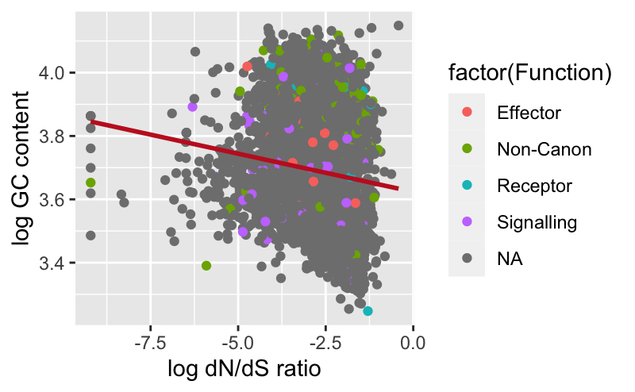

```r
p2 <- ggplot(dvg3, aes(x = log(dN.dS), y = log(GeneAverage))) +
  geom_point(aes(color = factor(Function))) +
  stat_smooth(method = "lm",
        col = "#C42126",
        se = FALSE,
        size = 1) +
  xlab("log dN/dS ratio") +
  ylab("log GC content")

p2
```

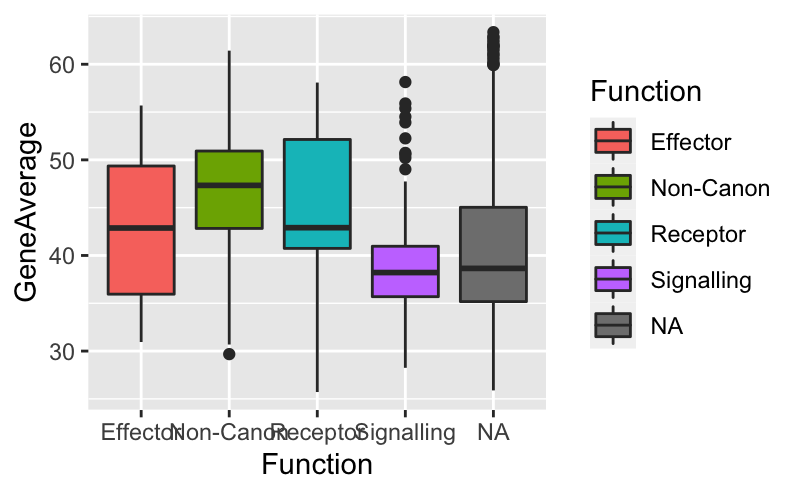

```r
p3 <- ggplot(dvg3, aes(x=Function, y=GeneAverage, fill = Function)) +
  geom_boxplot()

p3
```

And dN.dS …

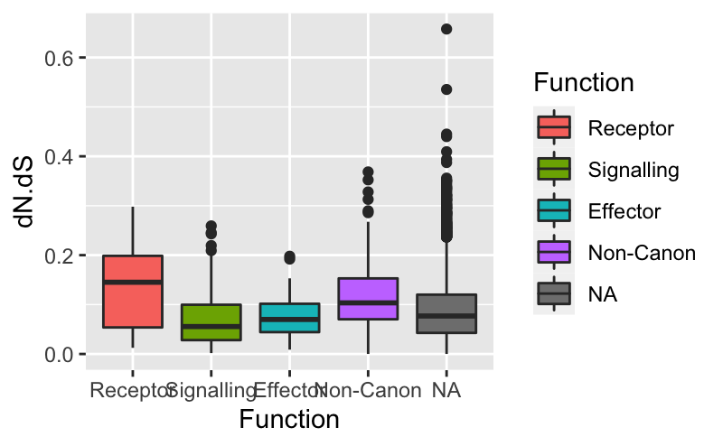

```r
dvg3$Function <- factor(dvg3$Function, levels=c("Receptor",
                                                "Signalling", "Effector",
                                                "Non-Canon", "NA"))

p3 <- ggplot(dvg3, aes(x=Function, y=dN.dS, fill = Function)) +
  geom_boxplot()

p3
```

```r
png("Plots/PrelimdN.dS.png")
p3
dev.off
```

[output not shown]

Hmm. I’m gonna have to look at some of these alignments that have high dNdS ….

|  | Gene | dN.dS | AlnLength | GeneAverage | Function | Codon | GCProp |
| --- | --- | --- | --- | --- | --- | --- | --- |
| 12 | apd-3 | 0.30380 | 744 | 62.89091 | NA | 248 | 0.6289091 |
| 121 | LOC100576167 | 0.39390 | 867 | 42.50909 | NA | 289 | 0.4250909 |
| 155 | LOC100576346 | 0.31360 | 3270 | 31.24909 | NA | 1090 | 0.3124909 |
| 195 | LOC100576532 | 0.31215 | 378 | 34.94455 | NA | 126 | 0.3494455 |
| 207 | LOC100576610 | 0.34425 | 1344 | 29.94364 | NA | 448 | 0.2994364 |
| 211 | LOC100576640 | 0.32165 | 2784 | 47.57727 | NA | 928 | 0.4757727 |
| 215 | LOC100576662 | 0.40934 | 213 | 48.27091 | NA | 71 | 0.4827091 |
| 424 | LOC100577803 | 0.35590 | 762 | 27.96545 | NA | 254 | 0.2796545 |
| 430 | LOC100577845 | 0.33579 | 2436 | 37.13182 | NA | 812 | 0.3713182 |
| 461 | LOC100577982 | 0.30275 | 594 | 34.80273 | NA | 198 | 0.3480273 |

[output cut: 35 more lines]

```r
highomega <- as.data.frame(dvg3$Gene[dvg3$dN.dS > 0.3])
write.table(highomega, "output/highomega.txt", col.names = F, row.names = F, quote = F)
```

So I went away and looked through those alignments and took out 3 for seeming to have shifted a reading frame or having a species where the protein is no longer predicted.

|  | Gene | dN.dS | AlnLength | GeneAverage | Function | Codon | GCProp |
| --- | --- | --- | --- | --- | --- | --- | --- |
| 684 | LOC102654160 | 0.30070 | 1458 | 45.14818 | NA | 486 | 0.4514818 |
| 5543 | LOC726460 | 0.32054 | 330 | 46.88636 | NA | 110 | 0.4688636 |
| 5784 | LOC727165 | 0.35158 | 498 | 57.97455 | NA | 166 | 0.5797455 |

Plot again …

```r
dvg4 <- dvg3[!dvg3$Gene %in% remaln,]

library("stringr")
dvg4$Function <- str_replace_na(dvg4$Function, replacement = "Background")
dvg4$Function[dvg4$Function == "Non-Canon"] <- "Non-Canon Immune"

head(dvg4)
```

|  | Gene | dN.dS | AlnLength | GeneAverage | Function | Codon | GCProp |
| --- | --- | --- | --- | --- | --- | --- | --- |
| 1 | 5-HT1 | 0.08365 | 1152 | 54.80636 | Background | 384 | 0.5480636 |
| 2 | 5-ht7 | 0.12095 | 666 | 51.89727 | Background | 222 | 0.5189727 |
| 3 | A4 | 0.19851 | 510 | 43.77818 | Non-Canon Immune | 170 | 0.4377818 |
| 4 | Acph-1 | 0.20930 | 1185 | 41.02818 | Background | 395 | 0.4102818 |
| 5 | ACSF2 | 0.15856 | 888 | 49.78545 | Background | 296 | 0.4978545 |
| 6 | Adar | 0.03833 | 1671 | 44.76364 | Background | 557 | 0.4476364 |

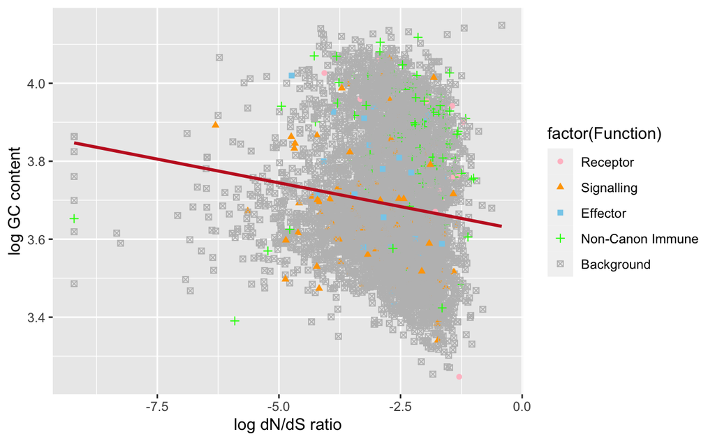

```r
dvg4$Function <- factor(dvg4$Function, levels=c("Receptor",
                                                "Signalling", "Effector",
                                                "Non-Canon Immune", "Background"))


p2 <- ggplot(dvg4, aes(x = log(dN.dS), y = log(GeneAverage))) +
  geom_point(aes(color = factor(Function), shape = factor(Function))) +
  scale_color_manual(values = c("Receptor" = "pink",
                                "Signalling"="orange",
                                "Effector"="skyblue",
                                "Non-Canon Immune"="green",
                                "Background"="gray")) +
  stat_smooth(method = "lm",
        col = "#C42126",
        se = FALSE,
        size = 1) +
  xlab("log dN/dS ratio") +
  ylab("log GC content")

p2
```

```r
dvg4$Immune <- ifelse(dvg4$Function == "Background", "0", "1")
dvg4$Class[dvg4$Function == "Background"] <- "Background"
dvg4$Class[dvg4$Function == "Non-Canon Immune"] <- "Non-Canon"
dvg4$Class <- str_replace_na(dvg4$Class, replacement = "Canon Immune")
head(dvg4, n= 40)
```

|  | Gene | dN.dS | AlnLength | GeneAverage | Function | Codon | GCProp | Immune | Class |
| --- | --- | --- | --- | --- | --- | --- | --- | --- | --- |
| 1 | 5-HT1 | 0.08365 | 1152 | 54.80636 | Background | 384 | 0.5480636 | 0 | Background |
| 2 | 5-ht7 | 0.12095 | 666 | 51.89727 | Background | 222 | 0.5189727 | 0 | Background |
| 3 | A4 | 0.19851 | 510 | 43.77818 | Non-Canon Immune | 170 | 0.4377818 | 1 | Non-Canon |
| 4 | Acph-1 | 0.20930 | 1185 | 41.02818 | Background | 395 | 0.4102818 | 0 | Background |
| 5 | ACSF2 | 0.15856 | 888 | 49.78545 | Background | 296 | 0.4978545 | 0 | Background |
| 6 | Adar | 0.03833 | 1671 | 44.76364 | Background | 557 | 0.4476364 | 0 | Background |
| 7 | Adk1 | 0.09630 | 567 | 41.26909 | Background | 189 | 0.4126909 | 0 | Background |
| 8 | Akhr | 0.08289 | 1020 | 38.17364 | Background | 340 | 0.3817364 | 0 | Background |
| 9 | Amel_8916 | 0.06404 | 642 | 43.33091 | Background | 214 | 0.4333091 | 0 | Background |
| 10 | Ant | 0.07417 | 837 | 47.27909 | Background | 279 | 0.4727909 | 0 | Background |

[output cut: 30 more lines]

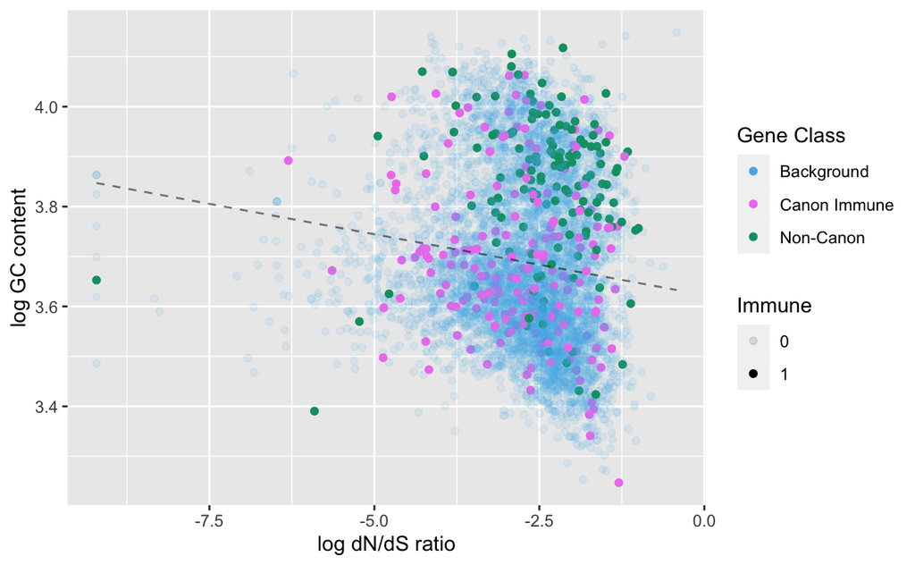

```r
p2 <- ggplot(dvg4, aes(x = log(dN.dS), y = log(GeneAverage))) +
  geom_point(aes(color = Class, alpha = Immune)) +
  scale_color_manual(values = c("#56B4E9",
                               "violet",
                               "#009E73",
                                "#F0E442",
                                "gray"),
                     name = "Gene Class") +
  #scale_alpha_manual(values = c(0.25, 5), guide = "none") +
   geom_line(stat="smooth",method = "lm",
              size = .5,
              linetype ="dashed",
              alpha = 0.5) +
        xlab("log dN/dS ratio") +
        ylab("log GC content")

p2
```

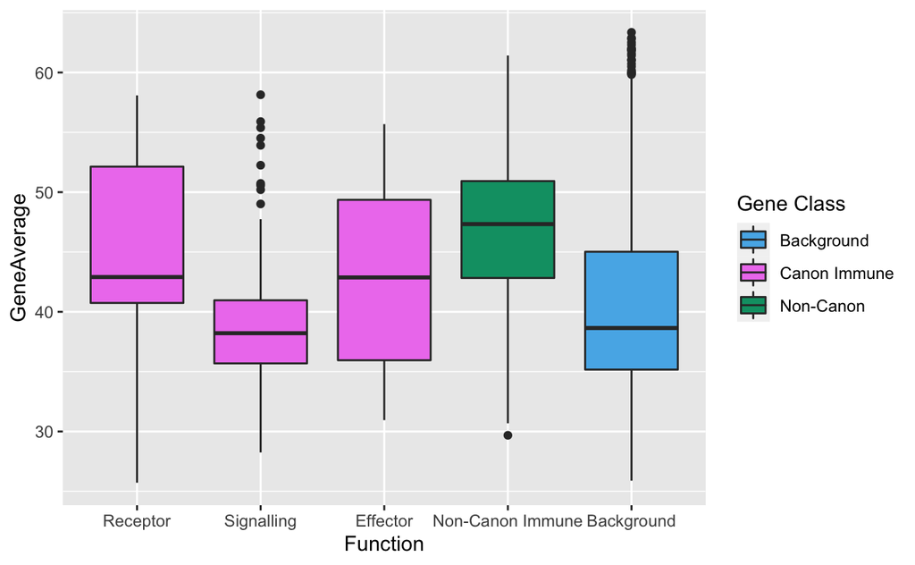

```r
p3 <- ggplot(dvg4, aes(x=Function, y=GeneAverage, fill = Class)) +
  geom_boxplot() +
  scale_fill_manual(values = c("#56B4E9",
                               "violet",
                               "#009E73",
                                "#F0E442",
                                "gray"),
                    name = "Gene Class")

p3
```

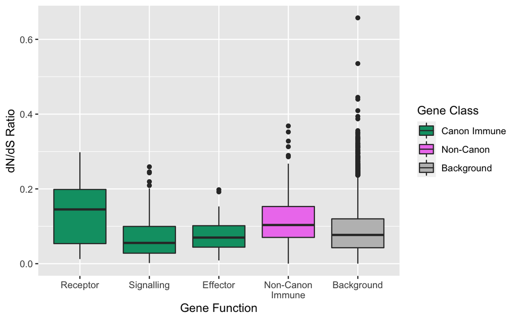

```r
dvg4$Class <- factor(dvg4$Class, levels=c("Canon Immune",
                                                "Non-Canon",
                                                "Background"))

p3.2 <- ggplot(dvg4) +
  geom_boxplot(aes(x=Function, y=dN.dS, fill = Class)) +
  scale_fill_manual(values = c("#009E73",
                               "violet",
                               "gray"),
                    name = "Gene Class") +
  scale_x_discrete(labels = function(x) str_wrap(x, width = 10)) +
  xlab("Gene Function") +
  ylab("dN/dS Ratio")

p3.2
```

Write up Table

|  | Gene | Function | Class | dN.dS | AlnLength | GeneAverage | Codon | GCProp | Immune |
| --- | --- | --- | --- | --- | --- | --- | --- | --- | --- |
| 1 | 5-HT1 | Background | Background | 0.08365 | 1152 | 54.80636 | 384 | 0.5480636 | 0 |
| 2 | 5-ht7 | Background | Background | 0.12095 | 666 | 51.89727 | 222 | 0.5189727 | 0 |
| 3 | A4 | Non-Canon Immune | Non-Canon | 0.19851 | 510 | 43.77818 | 170 | 0.4377818 | 1 |
| 4 | Acph-1 | Background | Background | 0.20930 | 1185 | 41.02818 | 395 | 0.4102818 | 0 |
| 5 | ACSF2 | Background | Background | 0.15856 | 888 | 49.78545 | 296 | 0.4978545 | 0 |
| 6 | Adar | Background | Background | 0.03833 | 1671 | 44.76364 | 557 | 0.4476364 | 0 |